# Test A Perceptual Phenomenon

Raghav

19 July 2017

# TEST A PERCEPTUAL PHENOMENON

### 1. Declaring the variables

We want to measure how the type of the Stroop experimental condition (Congruent/Incongruent) affects the time taken to name all the ink colors.

Therefore, our independent variable would be **the Stroop experiment condition**.

Our dependent variable, then, would be **the time taken to complete the tasks in the experiment condition (name all the ink colors)**.

### 2. Hypothesis and statistical test

#### Hypothesis

With our definition of the independent and dependent variables above, our hypothesis would check, we want to see if there is an increase in the time taken in the Incongruent experimental condition.

Let the means for the time taken for the Congruent and Incongruent experimental condition be $\mu_{C}$ and $\mu_{I}$ respectively.

Our null hypothesis would argue that there is no change or a significant increase in the time taken in the Congruent condition than in the Incongruent condition.

Therefore, our null hypothesis, $H_{0}$ would be: $\mu_{C} \ge \mu_{I}$.

Our alternate hypothesis would argue that there the time taken in the Congruent condition is significantly less than the time taken in the Incongruent condition.

Thus, our alternate hypothesis, $H_{A}$ would be: $\mu_{C} < \mu_{I}$.

#### Statistical test

Since we comparing **differences in means** of the same individuals (**related groups**) who were in both conditions and all we have to begin with is a **sample** of 24 people, we should proceed with the *dependent t-test/paired samples t-test*.

There are several assumptions that must be fulfilled inorder for us to use this t-test:

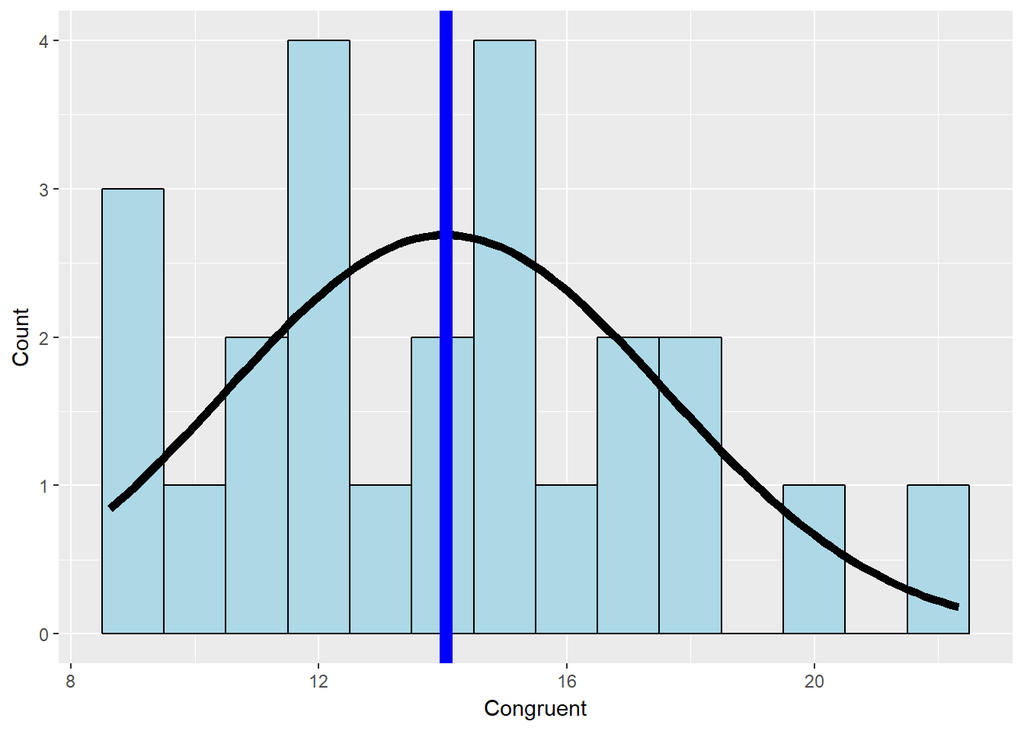

The blue line represents the mean value.

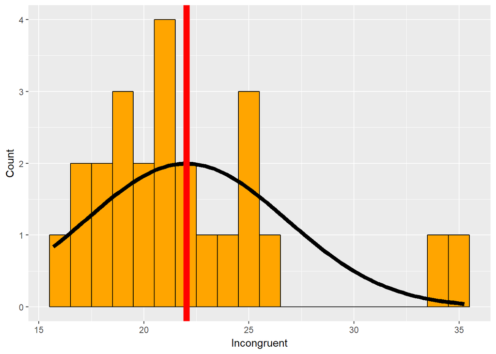

The red line represents the mean value.

While, these look normally distributed, we can confirm this fact analytically using the Shapiro-Wilk test (checks normality; statistically significant levels mean that the data is **NOT** normally distributed).

```
##
##  Shapiro-Wilk normality test
##
## data:  stroop$Congruent
## W = 0.97092, p-value = 0.6898
```

The p-value for the Congruent data is *MUCH* greater than 0.05, which means the result is not statistically significant. Thus, the data is normally distributed.

```
##
##  Shapiro-Wilk normality test
##
## data:  stroop$Incongruent
## W = 0.85395, p-value = 0.00259
```

The p-value for the Incongruent data is lower than 0.05, which means the result is statistically significant. However, the point to notice here is that we need an APPROXIMATELY normal curve, and this data would fail to be statistically significant at lower levels (0.001). Thus, while the result is not as promising, we can still take this data to be normally distributed for our purposes.

*Thus, the data is normally distributed.*

4. A **large sample size** is used. *This is true, also by assumption.*

5.There should be no significant outliers. *Outliers are any points 1.5 x IQR below Q1 or 1.5 IQR above Q3. Let us check this.*

```
## [1] "5.437"  "22.659"
```

The above is the ‘normal’ range for values in this dataframe.

```
## [1] "8.63"   "22.328"
```

These are the minimum and maximum values in this dataframe. It is apparent from this that there are no outliers in the Congruent dataframe

```
## [1] "10.714625" "32.053625"
```

The above is the ‘normal’ range for values in this dataframe.

```
## [1] "15.687" "35.255"
```

These are the minimum and maximum values in this dataframe.

It is apparent from this that there is atleast one outlier (35.255) in the Incongruent dataframe, but this is a minor outlier and **NOT** significant.

**Thus, this t-test can be used.**

### 3. Looking at the data

Let us look at this data a little more closely. We already looked at the plots of both datasets (Congruent & Incongruent) above. Let us look at some other data.

```
##    Congruent      Incongruent
##  Min.   : 8.63   Min.   :15.69
##  1st Qu.:11.90   1st Qu.:18.72
##  Median :14.36   Median :21.02
##  Mean   :14.05   Mean   :22.02
##  3rd Qu.:16.20   3rd Qu.:24.05
##  Max.   :22.33   Max.   :35.26
```

CENTRAL TENDENCY:

1. Mean: Congruent: 14.05 Incongruent: 22.02
2. Median: Congruent: 14.36 Incongruent: 21.02

VARIABILITY:

1. Range: Congruent:

```
## [1] 13.698
```

Incongruent:

```
## [1] 19.568
```

2. Standard Deviation: Congruent:

```
## [1] 3.559358
```

Incongruent:

```
## [1] 4.797057
```

### 4. Visualizations

As mentioned, these were already created above. Here, I recreate them for convenience.

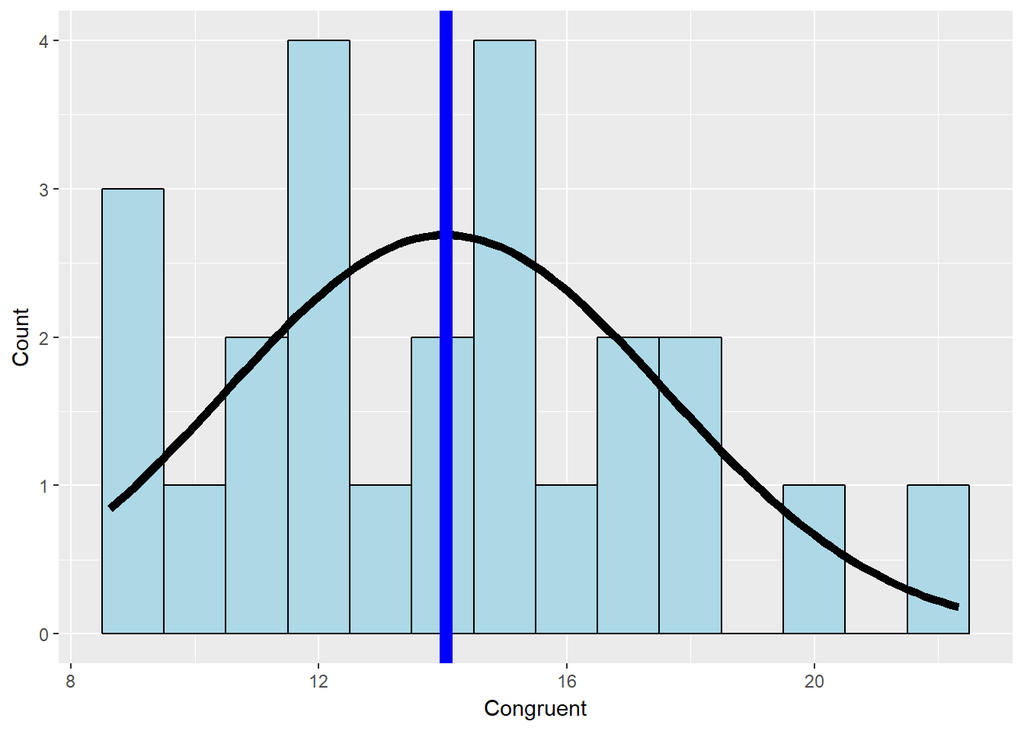

The blue line represents the mean value.

It seems apart from the bar at 15, the data is pretty normally distributed.

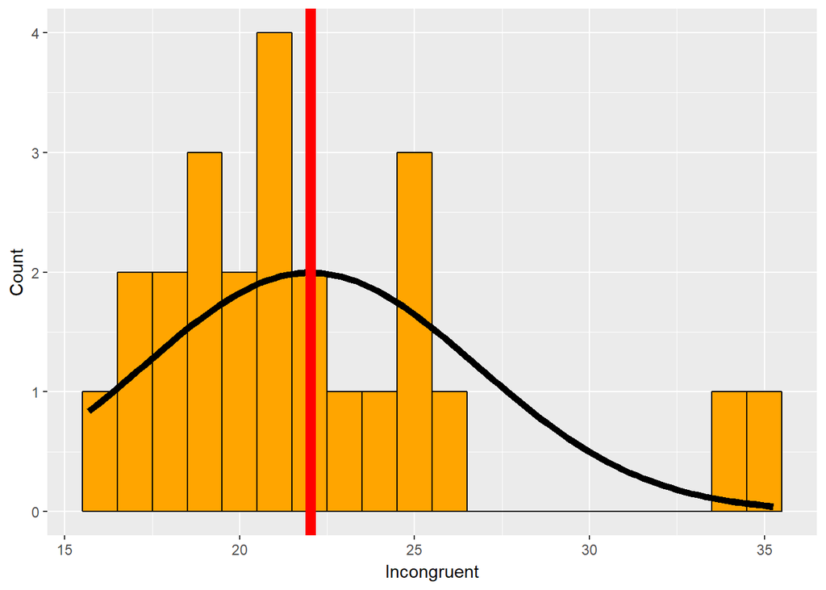

The red line represents the mean value.

It seems that, once again, there is a peak at 25. Apart from that, there is a significant gap between 26 and 34, which is probably responsible for the deviation from ‘normality’ for this plot.

### 5. Performing the statistical test

We will perform a one-tailed t-test, because we want to see if there is an increase in the time taken in the Incongruent experimental condition.

```
## [1] -7.965
```

Note that the difference is **negative** because on average, it takes more time in the Incongruent experimental condition.

The standard deviation, $\sigma$, of the sample is:

```
## [1] 4.865
```

The degrees of freedom, $df$, are:

```
## [1] 23
```

The sample error, $s$, is:

```
## [1] 0.993
```

The t-statistic is:

```
## [1] -8.021
```

The t-critical value for a one-tailed test an $\alpha$ level (*p-value*) of 0.05 is:

```
## [1] -1.714
```

Our t-statistic is much larger in magnitude than the t-critical value! Using GraphPad, the significance is less than 0.0001!

This implies that our result is statistically significant, and we thus **reject the null**!

This implies that participants in the Congruent condition took significant less time than those in the Incongruent condition.

Therefore, the type of the experimental condition had a casual effect on the time taken.

This is very much believable: our brains find it much easier to comprehend words that are the same color the text reads (*semantic facilitation*). Reading written word colors in different colors than the text may our brains work much harder (*Stroop asynchrony*).

```
## [1] -9.667002 -6.262998
```

This was the mean difference in my scores:

```
## [1] -18.47
```

This value is alarmingly high! Some reasons for this could be: 1. I didn’t take the test in a quiet ‘experiment’ room 2. I was cognizant of some facts about the experiment beforehand

### 6. Reason for effects

There are several reaons for the lag in times taken:

Related to the standard Stroop effect, the emotional Stroop test works by examining the response time of the participant to name colors of negative emotional words. For example, depressed participants will be slower to say the color of depressing words rather than non-depressing words. Non-clinical subjects have also been shown to name the color of an emotional word (e.g., “war”, “cancer”, “kill”) slower than naming the color of a neutral word (e.g., “clock”, “lift”, “windy”).

### References

1. https://en.wikipedia.org/wiki/Stroop_effect
2. https://en.wikipedia.org/wiki/Emotional_Stroop_test